# Lab_3

**Lab Report Title**  
*Differential and Operational Amplifier*

**Course:** ELECTRONICS 2

**Date:** 11/06/2025

**Group Members**

| Full Name | Matriculation No. |
| --- | --- |
| Ashu Nkongho Tekoh | 2756129 |
| Enes Gjana | 2770615 |
| Elhama Adel | 2756781 |

```python
#Load all Import

%load_ext autoreload
%autoreload 2
```

```
The autoreload extension is already loaded. To reload it, use:
  %reload_ext autoreload
```

# Introduction and Objective

# Preparation

## Part 1: Differential Amplifier

**Objective:** Record transfer characteristics of a differential amplifier, determine the offset voltage and transconductance.

1. **Calculation of the emitter resistance RE for the given OP.**
   $$RE = \frac{U_B-U_{\rm BE0}}{2*I_{\rm CO}} = \frac{9.35\text{ V}}{2\text{ mA}} = {4675\;\Omega}.$$
2. **Calculation of the Collector resistance RC.**
   - This was not required in the preperation but the differential amplifier can not work without RC as the circuit provided had no RC.
   - The OP was assumed at $U_{B}$/2. $$U_{\rm OUT0} = \frac{U_B}{2} = {5\text{V}}.$$ $$RC = \frac{U_B-U_{\rm OUT0}}{I_{\rm CO}} = \frac{5\text{ V}}{1\text{ mA}} = {5000\;\Omega}.$$
3. **Simulation action (See Calculation under Data Processing)**
   - Build the differential amplifier circuit in SPICE / LT-Spice.
   - Perform the DC sweep of $U_{IN1}$ from -0.15V to 0.15V.
   - Plot $U_{OUT1}$ and $U_{OUT2}$.
   - Observe the transfer characteristics..

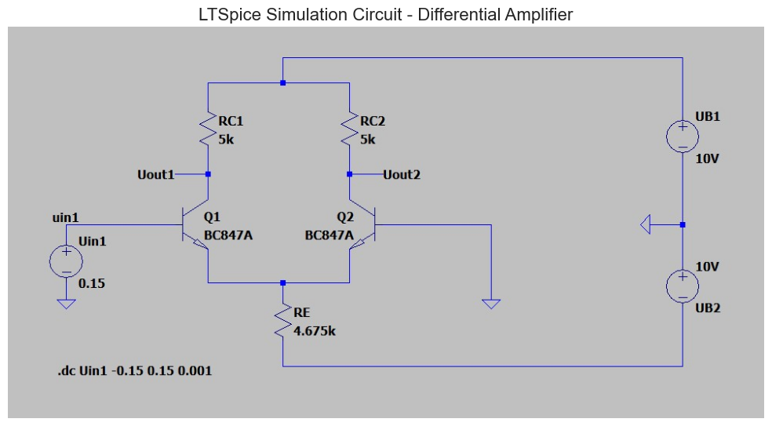

```python
from components.data_visualizing import insert_circut_diagram

# change to TRUE is we have Simulation Circuit Image
# Provide to the image folder, change the name to match

IS_LTSPICE_CIRCUIT_AVAILABLE = True
img_path = '../images/lab3_task1.jpg'  # change string to name of LTspice image
img_title = "LTSpice Simulation Circuit - Differential Amplifier" # Enter Image Title Here

if IS_LTSPICE_CIRCUIT_AVAILABLE:
    insert_circut_diagram(img_path=img_path,img_title=img_title)
```

```python
from components.data_import import import_measurement_data, import_simulation_data
from components.data_processing import process_sim_data,process_single_csv
import pandas as pd
# Use the code below if we want to read single .csv files
# Pull a .csv and .txt files in the data folder

IS_DATA_AVAILABLE = True
simulation_data_path = "../data/Prep_Data/diffamp_standard_transfer_characteristics.txt" # Enter path to simulation data
part_2_data_path = "../data/Prep_Data/OpAmp741.1.txt" # Enter path to simulation data
simulation_square_wave_data_path = "../data/Prep_Data/OpAmp741_2.txt" # Enter path to simulation square wave data
oscilloscope_data_path_w1 = "../data/Prep_Data/tek0000ALL.csv" # Enter path to chanel 1 oscilloscope data
oscilloscope_data_path_w2 = "../data/Prep_Data/tek0001ALL.csv" # Enter path to chanel 2 osilloscope data
task_2_2_data_path = "../data/Prep_Data/tek0000AELL2.2.csv"

cleaned_sim_data = pd.DataFrame()
cleaned_ch1_data = pd.DataFrame()
cleaned_ch2_data = pd.DataFrame()

part_2_data = pd.DataFrame()

if IS_DATA_AVAILABLE:
    sim_data = import_simulation_data(simulation_data_path)
    data_2 = import_simulation_data(part_2_data_path)
    data_3 = import_simulation_data(simulation_square_wave_data_path)
    w1_data = import_measurement_data(oscilloscope_data_path_w1)
    w2_data = import_measurement_data(oscilloscope_data_path_w2)
    task_2_2_data = import_measurement_data(task_2_2_data_path)

    # Processing the data

    #cleaned_sim_data = process_sim_data (sim_data)
    #part_2_data = process_sim_data (data_2)
    cleaned_w1_data = process_single_csv(w1_data)
    cleaned_w2_data =process_single_csv(w2_data)
    cleaned_task_2_2_data = process_single_csv(task_2_2_data)
```

```
[ 15-06-2025, 21:30:30 ] 20 root - INFO - Successfully imported simulation data from ../data/Prep_Data/diffamp_standard_transfer_characteristics.txt
```

|  | uin1 | V(uout1) | V(uout2) | abs(D(V(uout1)-V(uout2))/D(uin1)) |
| --- | --- | --- | --- | --- |
| 0 | -0.150 | 9.966732 | 0.112030 | 2.573565 |
| 1 | -0.149 | 9.965443 | 0.113314 | 2.675440 |
| 2 | -0.148 | 9.964051 | 0.114700 | 2.805822 |
| 3 | -0.147 | 9.962631 | 0.116114 | 2.890255 |
| 4 | -0.146 | 9.961155 | 0.117584 | 3.003672 |

```
[ 15-06-2025, 21:30:30 ] 20 root - INFO - Successfully imported simulation data from ../data/Prep_Data/OpAmp741.1.txt
```

|  | time | V(n002) | V(n003) |
| --- | --- | --- | --- |
| 0 | 0.000000e+00 | 0.010916 | 0.000000 |
| 1 | 1.554017e-07 | 0.010943 | 0.000076 |
| 2 | 3.108035e-07 | 0.011031 | 0.000151 |
| 3 | 4.662052e-07 | 0.011180 | 0.000227 |
| 4 | 6.216070e-07 | 0.011391 | 0.000303 |

```
[ 15-06-2025, 21:30:30 ] 20 root - INFO - Successfully imported simulation data from ../data/Prep_Data/OpAmp741_2.txt
```

|  | time | V(n002) | V(n003) |
| --- | --- | --- | --- |
| 0 | 0.000000e+00 | 13.88938 | -7.500000 |
| 1 | 9.918213e-12 | 13.89006 | -7.351227 |
| 2 | 1.022339e-11 | 13.89008 | -7.346649 |
| 3 | 1.083374e-11 | 13.89012 | -7.337494 |
| 4 | 1.205444e-11 | 13.89019 | -7.319183 |

```
[ 15-06-2025, 21:30:30 ] 34 root - INFO - Successfully imported measurement data from ../data/Prep_Data/tek0000ALL.csv
```

|  | TIME | CH1 | CH2 |
| --- | --- | --- | --- |
| 0 | -0.002000 | 0.093234 | 0.033750 |
| 1 | -0.002000 | 0.094531 | 0.034375 |
| 2 | -0.001999 | 0.094391 | 0.024219 |
| 3 | -0.001999 | 0.094484 | 0.030469 |
| 4 | -0.001998 | 0.094984 | 0.030000 |

```
[ 15-06-2025, 21:30:30 ] 34 root - INFO - Successfully imported measurement data from ../data/Prep_Data/tek0001ALL.csv
```

|  | TIME | CH1 | CH2 |
| --- | --- | --- | --- |
| 0 | -0.002000 | 0.094281 | 1.90922 |
| 1 | -0.002000 | 0.094672 | 1.91375 |
| 2 | -0.001999 | 0.094687 | 1.91875 |
| 3 | -0.001999 | 0.095391 | 1.91594 |
| 4 | -0.001998 | 0.095062 | 1.91141 |

```
[ 15-06-2025, 21:30:30 ] 34 root - INFO - Successfully imported measurement data from ../data/Prep_Data/tek0000AELL2.2.csv
```

|  | TIME | CH1 | CH2 |
| --- | --- | --- | --- |
| 0 | -0.000201 | -6.92578 | 10.6734 |
| 1 | -0.000201 | -6.98203 | 10.7219 |
| 2 | -0.000201 | -6.94609 | 10.6813 |
| 3 | -0.000201 | -6.92500 | 10.6094 |
| 4 | -0.000201 | -6.96172 | 10.6750 |

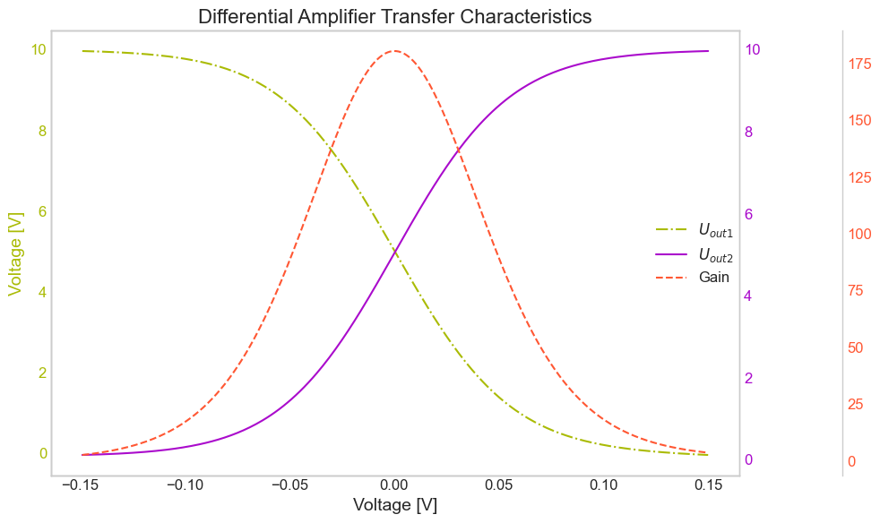

```python
# Plotting multiple data
from components.data_visualizing import plot_multiple_sim_data_2, plot_sim_data
PLOT_MULTI_SIM_DATA = True

if PLOT_MULTI_SIM_DATA:
    fig = plot_multiple_sim_data_2(
        sim_data=sim_data,
        x_label='Voltage [V]',
        y1_label= 'Voltage [V]',
        title='Differential Amplifier Transfer Characteristics',
        label1='$U_{out1}$',
        label2='$U_{out2}$',
        label3='Gain',
        #is_multi=True
    )
```

**Transconductance and the offset voltage**

1. From the simulation in LTSpice we were able to record an offset voltage of 0.05 mV.
2. The transconductance was calculated using the formula $$g_m = \frac{I_{\text{co}}}{2*U_{\text{T}}}$$ and we got 20 mS.

[figure not shown]

```python
from components.data_visualizing import insert_circut_diagram

# change to TRUE is we have Simulation Circuit Image
# Provide to the image folder, change the name to match

IS_LTSPICE_CIRCUIT_AVAILABLE = True
img_path = '../images/tek00000.png'  # change string to name of LTspice image
img_title = "Oscilloscope Screenshot" # Enter Image Title Here

if IS_LTSPICE_CIRCUIT_AVAILABLE:
    insert_circut_diagram(img_path=img_path,img_title=img_title)
```

[figure not shown]

```python
from components.data_visualizing import insert_circut_diagram

# change to TRUE is we have Simulation Circuit Image
# Provide to the image folder, change the name to match

IS_LTSPICE_CIRCUIT_AVAILABLE = True
img_path = '../images/tek00001.png'  # change string to name of LTspice image
img_title = "Oscilloscope Screenshot" # Enter Image Title Here

if IS_LTSPICE_CIRCUIT_AVAILABLE:
    insert_circut_diagram(img_path=img_path,img_title=img_title)
```

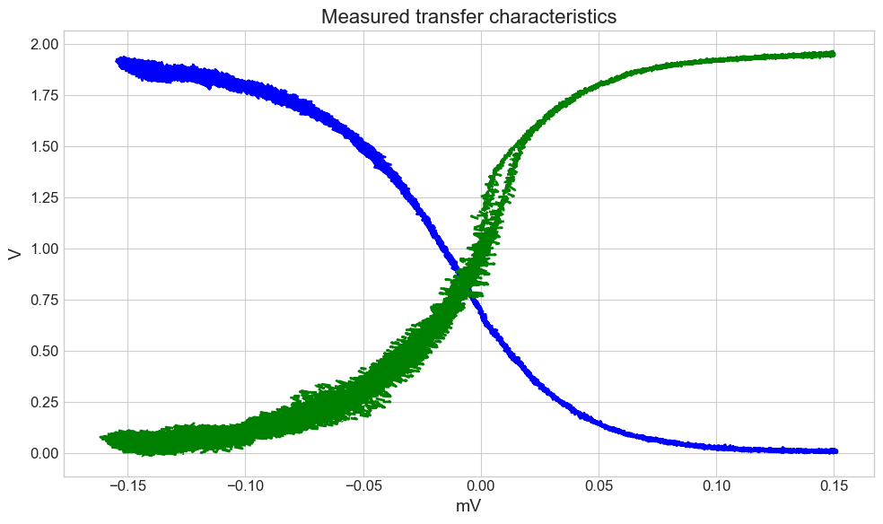

```python
from components.data_visualizing import plot_two_xy
plot_two_xy(
    cleaned_w1_data, cleaned_w2_data,
    x1='CH1', y1='CH2',
    x2='CH1', y2='CH2',
    label1='',
    label2='',
    x_label='mV',
    y_label='V',
    title='Measured transfer characteristics',
)
```

**Evaluation 1**

1. The offset voltage can be clearly seen that it is approximately 0.02 mV.
2. To calculate the transconductance we found the slope of the blue line by getting two points and calculating the difference between  
   them and ended up with 16mS.

   $$g_m = \frac{X2-X1}{Y2-Y1}$$ $$g_m = \frac{-0.25}{-0.015}$$ $$g_m = 16mS$$

## Task 1.2

**Objective:** calculate the theoritical values of common mode gain and differential mode gain for the modified circuit with RC=1k.

1. **Common mode gain.**
   Given: $$R_C = 1\,\text{k}\Omega, \quad R_E = 4.675\,\text{k}\Omega$$ $$A_{CM} = -\frac{1\,\text{k}\Omega}{2 \cdot 4.675\,\text{k}\Omega} = -\frac{1}{9.35} = -0.106$$
2. **Differential mode gain**
   $$A_{DM} = \frac{1}{2}g_m R_C$$ $$g_m = \frac{I_{\rm CO}}{2*V_T}$$

Given: $$I_C = 1\,\text{mA}, \quad V_T = 25\,\text{mV}, \quad R_C = 1\,\text{k}\Omega$$

$$g_m = \frac{1\,\text{mA}}{50\,\text{mV}} = 20\,\text{mS}$$

$$A_{DM} = 10\,\text{mS} \cdot 1000\,\text{}\Omega = 10$$

[figure not shown]

```python
from components.data_visualizing import insert_circut_diagram

# change to TRUE is we have Simulation Circuit Image
# Provide to the image folder, change the name to match

IS_LTSPICE_CIRCUIT_AVAILABLE = True
img_path = '../images/tek000001_2.png'  # change string to name of LTspice image
img_title = "Oscilloscope Screenshot" # Enter Image Title Here

if IS_LTSPICE_CIRCUIT_AVAILABLE:
    insert_circut_diagram(img_path=img_path,img_title=img_title)
```

**Evaluation 1.2**

1. As we can see in the picture above, Ch1 measures the voltage of the collector at transistor T1, and CH2 measures the voltage of the collector of transistor 2. With this information the gain for each transistir is calculated below:

$$A_{u_d1} = \frac{U_{\text{out1}}}{U_{\text{in}}} = \frac{490}{9.83}=49.87$$ $$A_{u_d2} = \frac{U_{\text{out1}}}{U_{\text{in}}} = \frac{483.4}{9.83}=49.17$$

2. Next the differential amplifier was switched to common mode, and for the common mode the input voltage was increased until the voltage of 490mV from the prevoious experiment was recorded. For this output voltage to be achieved 1.63V as input were required.

$$A_{u_{\text{cm}}} = \frac{U_{\text{out1}}}{U_{\text{in}}} = \frac{0.49}{1.63}=0.3$$

3. From these obtained gains we can now calculate common mode rejection ratio:

$$CMMR = \frac{A_{u_d}}{A_{u_{\text{cm}}}} = \frac{49.87}{0.3}=166$$

## Task 2.1

**Objective:** The goal is to measure the gain-bandwidth product of the 741 op-amp by using a non-inverting amplifier configuration. Determine the gain-bandwidth product (GBP) of the 741 op-amp using a non-inverting amplifier circuit. Verify that GBP remains constant across different closed-loop gains and compare it to the datasheet specification (typically 1 MHz for the 741).

1. **OpAmp741 Datasheet.**

The datasheet of OpAmp741 was downloaded from:

- Texas Instruments: [LM741 Datasheet](https://www.ti.com/product/LM741)
2. **General Characteristics.**

| **Parameter** | **Typical Value** | **Maximum Value** |
| --- | --- | --- |
| Input Offset Voltage | 2 mV | 6 mV |
| Input Bias Current | 80 nA | 500 nA |
| Input Offset Current | 20 nA | 200 nA |
| Input Resistance | 2 MΩ | — |
| Output Resistance | 75 Ω | — |
| Slew Rate | 0.5 V/μs | — |
| Gain Bandwidth Product | 1 MHz | — |
| Large Signal Voltage Gain | 200,000 (106 dB) | — |
| Common-Mode Rejection Ratio (CMRR) | 90 dB | — |
| Power Supply Rejection Ratio (PSRR) | 96 dB | — |
| Supply Voltage Range | ±3 V | ±22 V |
| Input Voltage Range | ±13 V | — |
| Output Voltage Swing | ±10 V (at ±15 V supply) | — |
| Power Consumption | 0.5 – 1.7 mW | — |
| Operating Temperature Range | -55°C | +125°C |

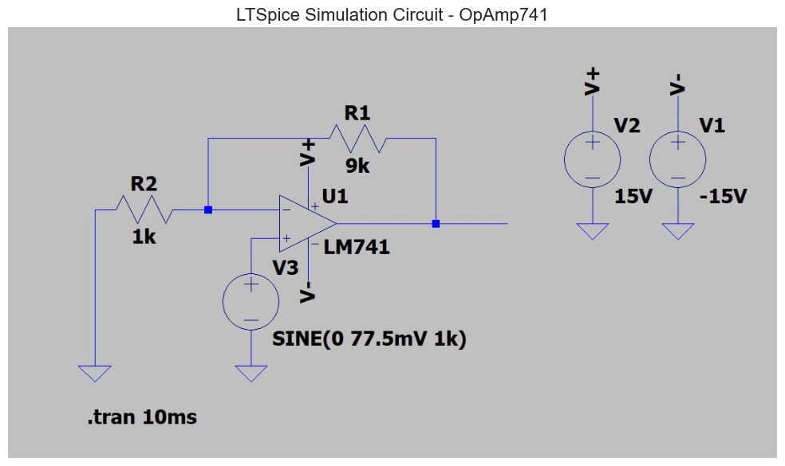

```python
from components.data_visualizing import insert_circut_diagram

# change to TRUE is we have Simulation Circuit Image
# Provide to the image folder, change the name to match

IS_LTSPICE_CIRCUIT_AVAILABLE = True
img_path = '../images/OpAmp741.jpg'  # change string to name of LTspice image
img_title = "LTSpice Simulation Circuit - OpAmp741" # Enter Image Title Here

if IS_LTSPICE_CIRCUIT_AVAILABLE:
    insert_circut_diagram(img_path=img_path,img_title=img_title)
```

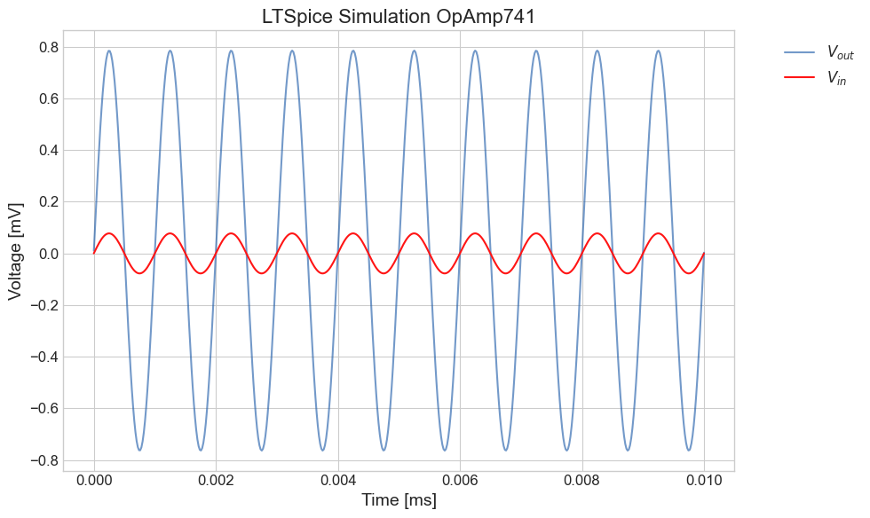

```python
# For Plotting Simulation Values

from components.data_visualizing import plot_sim_data
# Function requires 5 arguments, hover cursor to see
PLOT_SIM_DATA = True

pro_data_3 = data_2.copy()
#pro_data_3["time"] = pro_data_3["time"].astype(float)*1e3
#pro_data_3["V(out)"] = pro_data_3["V(out)"].astype(float)*1e3
#pro_data_3["V(vin)"] = pro_data_3["V(vin)"].astype(float)*1e3

if PLOT_SIM_DATA:
     fig, ax = plot_sim_data(
                    pro_data_3,
                    x_label="Time [ms]",
                    y_label="Voltage [mV]",
                    title="LTSpice Simulation OpAmp741",
                    label1="$V_{out}$",
                    label2="$V_{in}$",
                    is_multi=True,
                    color2="#ff1515",
                    color1="#1e5ca99f"
               )
```

**Evaluation 2.1**

1. During the lab session the following measurements were made by changing the amplification using the resistor R1, the value of R1 was 1k for a gain of 6dB, 10k for 20dB and 100k for 40dB.

### Amplification Data Table

| Gain | Frequency | ( U_{\text{in}} ) (V) | ( U_{\text{out}} ) (V) | Amplification Ratio |
| --- | --- | --- | --- | --- |
| 6 dB | 1k | 0.0749 | 0.15750 | 2.10 |
| 6 dB | 2K | 0.0749 | 0.16800 | 2.24 |
| 6 dB | 5K | 0.0749 | 0.17325 | 2.31 |
| 6 dB | 10K | 0.0749 | 0.17325 | 2.31 |
| 6 dB | 20K | 0.0749 | 0.17220 | 2.30 |
| 6 dB | 50K | 0.0749 | 0.16800 | 2.24 |
| 6 dB | 100K | 0.0749 | 0.15750 | 2.10 |
| 6 dB | 200K | 0.0749 | 0.15750 | 2.10 |
| 6 dB | 500K | 0.0749 | 0.10343 | 1.38 |
| 6 dB | 1M | 0.0749 | 0.06143 | 0.82 |
| 6 dB | 2M | 0.0749 | 0.04043 | 0.54 |
| 20 dB | 1k | 0.0748 | 0.8780 | 11.74 |
| 20 dB | 2K | 0.0750 | 0.8870 | 11.83 |
| 20 dB | 5K | 0.0752 | 0.9000 | 11.97 |
| 20 dB | 10K | 0.0755 | 0.9000 | 11.92 |
| 20 dB | 20K | 0.0765 | 0.8800 | 11.58 |
| 20 dB | 50K | 0.0759 | 0.7300 | 9.62 |
| 20 dB | 100K | 0.0755 | 0.50400 | 6.68 |
| 20 dB | 200K | 0.0755 | 0.27510 | 3.64 |
| 20 dB | 500K | 0.0750 | 0.11130 | 1.48 |
| 20 dB | 1M | 0.0760 | 0.06300 | 0.83 |
| 20 dB | 2M | 0.0750 | 0.04200 | 0.56 |
| 40 dB | 1k | 0.0749 | 6.31050 | 84.25 |
| 40 dB | 2K | 0.0749 | 7.57050 | 101.07 |
| 40 dB | 5K | 0.0749 | 7.17150 | 95.75 |
| 40 dB | 10K | 0.0749 | 4.88250 | 65.19 |
| 40 dB | 20K | 0.0749 | 2.65650 | 35.47 |
| 40 dB | 50K | 0.0749 | 1.05000 | 14.02 |
| 40 dB | 100K | 0.0749 | 0.52500 | 7.01 |
| 40 dB | 200K | 0.0749 | 0.27300 | 3.64 |
| 40 dB | 500K | 0.0749 | 0.16800 | 2.24 |
| 40 dB | 1M | 0.0749 | 0.13650 | 1.82 |
| 40 dB | 2M | 0.0749 | 0.12600 | 1.68 |

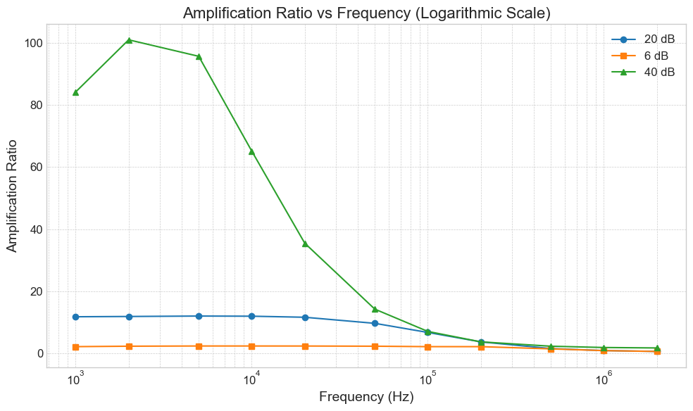

```python
import matplotlib.pyplot as plt
import numpy as np

# Example data for each gain level (use your full dataset here)
frequencies = np.array([1e3, 2e3, 5e3, 10e3, 20e3, 50e3, 100e3, 200e3, 500e3, 1e6, 2e6])  # in Hz

ampl_20db = [11.74, 11.83, 11.97, 11.92, 11.58, 9.62, 6.68, 3.64, 1.48, 0.83, 0.56]
ampl_6db  = [2.10, 2.24, 2.31, 2.31, 2.30, 2.24, 2.10, 2.10, 1.38, 0.82, 0.54]
ampl_40db = [84.25, 101.07, 95.75, 65.19, 35.47, 14.2, 7.01, 3.64, 2.24, 1.82, 1.68]

# Plot
plt.figure(figsize=(10, 6))
plt.semilogx(frequencies, ampl_20db, label='20 dB', marker='o')
plt.semilogx(frequencies, ampl_6db, label='6 dB', marker='s')
plt.semilogx(frequencies, ampl_40db, label='40 dB', marker='^')

# Labels and legend
plt.xlabel('Frequency (Hz)')
plt.ylabel('Amplification Ratio')
plt.title('Amplification Ratio vs Frequency (Logarithmic Scale)')
plt.grid(True, which='both', linestyle='--', linewidth=0.5)
plt.legend()
plt.tight_layout()

plt.show()
```

### Gain-Bandwidth Product (GBW) Calculation

To determine the **gain-bandwidth product** for each gain setting, we follow these steps:

Determine the **cut-off frequency** (where gain drops by -3 dB) and compute:

$$ \text{Gain-Bandwidth Product (GBW)} = \text{Linear Gain} \times \text{Cut-off Frequency (Hz)} $$

#### 1. **Maximum Gain (Linear)**

From measurements:

| Gain Setting | Maximum Gain |
| --- | --- |
| 20 dB | 11.97 |
| 6 dB | 2.31 |
| 40 dB | 101.07 |

#### 2. **-3 dB Gain Levels**

The -3 dB point is:

$$ G_{-3dB} = G_{\text{max}} \times \frac{1}{\sqrt{2}} \approx G_{\text{max}} \times 0.707 $$

| Gain Setting | Max Gain | -3 dB Level |
| --- | --- | --- |
| 20 dB | 11.97 | 8.46 |
| 6 dB | 2.31 | 1.63 |
| 40 dB | 101.07 | 71.45 |

#### 4. **Gain-Bandwidth Product**

$$ \text{GBW} = \text{Gain} \times \text{Cut-off Frequency} $$

| Gain Setting | Gain (Linear) | Cut-Off Frequency (Hz) | GBW (Hz) |
| --- | --- | --- | --- |
| 20 dB | 11.97 | 70,000 | 837,900 |
| 6 dB | 2.31 | 300,000 | 693,000 |
| 40 dB | 101.07 | 7,000 | 707,490 |

## Task 2.2

**Objective:** The goal is to determine the slew rate of the 741 op-amp by using an inverting amplifier configuration. The slew rate was determined from the simulation and compared to the one from the datasheet. Also the power bandwidth was determined and compared to the one from the simulation.

According to the datasheet of the μA741 operational amplifier:

$$ \boxed{\text{Slew Rate}_{\text{typical}} = 0.5\ \frac{V}{\mu s}} $$

**Slew rate fro the simulation**

To calculate the slew rate from a transient simulation:

$$ \text{Slew Rate} = \frac{\Delta V}{\Delta t} = \frac{V_2 - V_1}{t_2 - t_1} $$

Where:

- $V_1$ and $V_2$ are two voltage points during the linear ramp (typically on a rising or falling edge of the output),
- $t_1$ and $t_2$ are the corresponding time points.

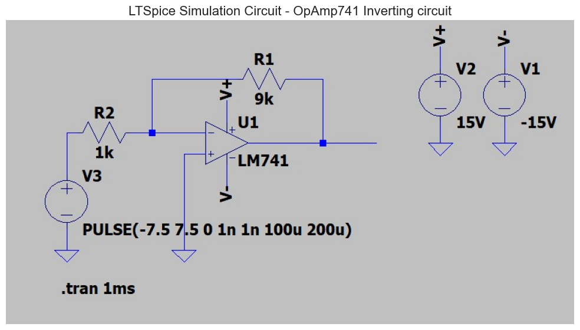

```python
from components.data_visualizing import insert_circut_diagram

# change to TRUE is we have Simulation Circuit Image
# Provide to the image folder, change the name to match

IS_LTSPICE_CIRCUIT_AVAILABLE = True
img_path = '../images/OpAmp741.2.jpg'  # change string to name of LTspice image
img_title = "LTSpice Simulation Circuit - OpAmp741 Inverting circuit" # Enter Image Title Here

if IS_LTSPICE_CIRCUIT_AVAILABLE:
    insert_circut_diagram(img_path=img_path,img_title=img_title)
```

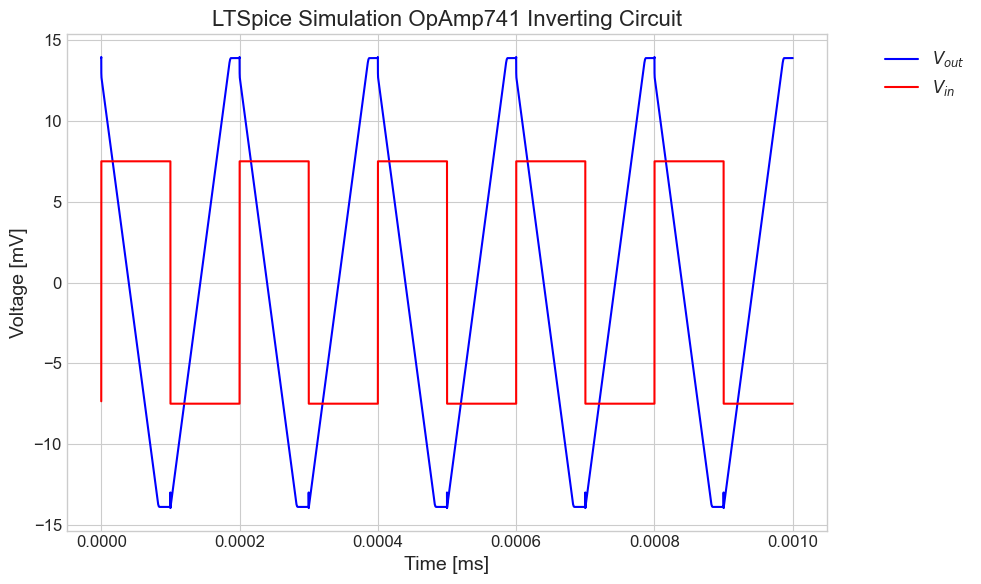

```python
# For Plotting Simulation Values

from components.data_visualizing import plot_sim_data
# Function requires 5 arguments, hover cursor to see
PLOT_SIM_DATA = True

pro_data_4 = data_3.copy()
#pro_data_3["time"] = pro_data_3["time"].astype(float)*1e3
#pro_data_3["V(out)"] = pro_data_3["V(out)"].astype(float)*1e3
#pro_data_3["V(vin)"] = pro_data_3["V(vin)"].astype(float)*1e3

if PLOT_SIM_DATA:
     fig, ax = plot_sim_data(
                    pro_data_4,
                    x_label="Time [ms]",
                    y_label="Voltage [mV]",
                    title="LTSpice Simulation OpAmp741 Inverting Circuit",
                    label1="$V_{out}$",
                    label2="$V_{in}$",
                    is_multi=True,
                    color1='blue',
                    color2='#FF0000'  # Red color for the second line
               )
```

**Slew Rate Calculation**

To calculate the slew rate:

$$ \text{Slew Rate} = \frac{U_1 - U_2}{T_1 - T_2} $$

Substitute the values:

$$ \text{Slew Rate} = \frac{13.85\ \text{V} - (-13.85\ \text{V})}{0.388\ \text{ms} - 0.300\ \text{ms}} = \frac{27.7\ \text{V}}{0.088\ \text{ms}} $$

Convert milliseconds to microseconds:

$$ \text{Slew Rate} = \frac{27.7\ \text{V}}{88\ \mu\text{s}} \approx \boxed{0.3159\ \frac{V}{\mu s}} $$

**Power bandwidth calculation**

To calculate the power bandwidth:

$$f_p=\frac{SR}{2*{\pi}*U_{\text{peak}}}$$ $$f_p=\frac{315900}{47.123}$$ $$f_p=6.7kHz$$

[figure not shown]

```python
# For Plotting Simulation Values

from components.data_visualizing import plot_sim_data
# Function requires 5 arguments, hover cursor to see
PLOT_SIM_DATA = True

pro_data_4 = cleaned_task_2_2_data.copy()
#pro_data_3["time"] = pro_data_3["time"].astype(float)*1e3
#pro_data_3["V(out)"] = pro_data_3["V(out)"].astype(float)*1e3
#pro_data_3["V(vin)"] = pro_data_3["V(vin)"].astype(float)*1e3

if PLOT_SIM_DATA:
     fig, ax = plot_sim_data(
                    pro_data_4,
                    x_label="Time [ms]",
                    y_label="Voltage [mV]",
                    title=" Measured waveforms for OpAmp741 Inverting Circuit",
                    label1="$V_{out}$",
                    label2="$V_{in}$",
                    is_multi=True,
                    color1='blue',
                    color2='#FF0000'  # Red color for the second line
               )
```

[figure not shown]

```python
from components.data_visualizing import insert_osc_screenshot

# change to TRUE is we have Simulation Circuit Image
# Provide to the image folder, change the name to match

IS_LTSPICE_CIRCUIT_AVAILABLE = True
img_path = '../images/tek000032.2.png'  # change string to name of LTspice image
img_title = "Op741 inverting circuit oscillscope screenshot." # Enter Image Title Here

if IS_LTSPICE_CIRCUIT_AVAILABLE:
    insert_osc_screenshot(img_path=img_path,img_title=img_title)
```

**Evaluation 2.2**

1. By using the screenshot above and the cursors of the oscilloscope the slew rate was calculated.

   $$ \text{Slew Rate} = \frac{U_1 - U_2}{T_1 - T_2} $$

   Substitute the values:

   $$ \text{Slew Rate} = \frac{24.81\ \text{V}}{0.044\ \text{ms}} $$

   Convert milliseconds to microseconds:

   $$ \text{Slew Rate} = \frac{24.81\ \text{V}}{44\ \mu\text{s}} \approx \boxed{0.563\ \frac{V}{\mu s}} $$

   The slew rate calculated from the oscilloscope is bigger than the one calculated from the simulation, that comes from the parasitic effects of different components.
2. By using this new slew rate the power bandwidth was also calculated and it also differs from the one in the simulation. It differs because if the slew rate increases so does the power bandwidth, because the U_peak is not changing.

   $$f_p=\frac{SR}{2*{\pi}*U_{\text{peak}}}$$ $$f_p=\frac{563000}{47.123}$$ $$f_p=11.947kHz$$